## Predicting Qualitative Outputs of Weight Lifting Exercises

#### Summary

The main objective of this study is to utilize a machine learning approach to predict qualitative outputs of weight lifting exercises. In the last few years the advancement of technology and proliferation of human activity tracker devices such as Jawbone Up, Nike FuelBand, and Fitbit has enabled researchers to collect large amounts of data about personal activity. The field of human activity recognition (HAR) has grown dramatically, reflecting its importance in many influential and important societal applications.

#### Exploratory Data Analysis

The data used in this study and more information are available at [Human Activity Recognition](http://groupware.les.inf.puc-rio.br/har#dataset) website. The dataset is comprise of information collected from accelerometers on the belt, forearm, arm, and dumbbell of 6 participants. They were asked to perform dumbbell lifts correctly and incorrectly in 5 different ways. According to HAR website the activates are categorized as follows: Class A: exactly according to the specification, Class B: throwing the elbows to the front, Class C: lifting the dumbbell only halfway, Class D: lowering the dumbbell only halfway and Class E: throwing the hips to the front.

Before building any models it is imperative to conduct some exploratory data analysis. In order to attain a better understand of the HAR dataset, first we start by loading all the required libraries and then load the training data into memory and replace all empty fields with NA to make the data processing easier. Also, the dataset contains “#DIV/0!” values which are MS Excel auto-generated error when a number is divided either by zero or string. Please note the following code assumes the data source files are located in your R Studio work directory.

```r
library(ggplot2)
library(lattice)
library(caret)
library(randomForest)
dataset <- read.csv("pml-training.csv", na.strings = c("NA", "", "#DIV/0!"))
```

Now we need to find out the size of the dataset and examining the internal structure of the dataset using dim() and summary() function for obtaining summary statistics. By examining the statistical information of summary table such as mean vs median we can identify outliers. Another indicator of an unusable variable is presence of high number of NA’s. However for the lack of space the code below just displays 4 variables: columns 13, 14, 159 and 160.

```r
dim(dataset)
```

```
## [1] 19622   160
```

```r
summary(dataset[,c(13:14,159,160)])
```

```
##  kurtosis_picth_belt kurtosis_yaw_belt magnet_forearm_z classe
##  Min.   :-2          Mode:logical      Min.   :-973     A:5580
##  1st Qu.:-1          NA's:19622        1st Qu.: 191     B:3797
##  Median : 0                            Median : 511     C:3422
##  Mean   : 4                            Mean   : 394     D:3216
##  3rd Qu.: 3                            3rd Qu.: 653     E:3607
##  Max.   :58                            Max.   :1090
##  NA's   :19248
```

The plot below shows the valum of each qualitative output classe.

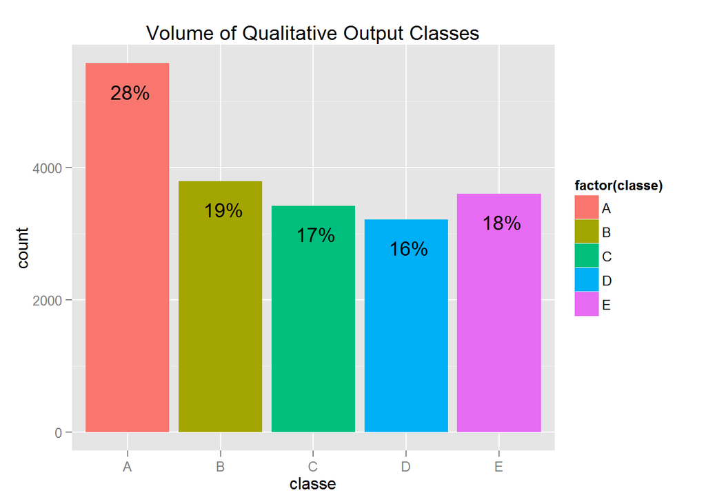

```r
qplot(x=classe, data=dataset, ymax=..count.., geom="bar", fill=factor(classe)
      , main="Volume of Qualitative Output Classes") +
stat_bin(aes(label = sprintf("\n\n %.0f%%", ..count../sum(..count..)*100)),geom="text")
```

#### Pre-processing

```r
dataset <- dataset[,colSums(is.na(dataset)) < 1920]
dataset <- dataset[,-c(1:7)]
```

Now that we have a reletvely cleaner dataset we need to split our training dataset into training and test for cross validation.

```r
inTrain <- createDataPartition(dataset$classe, p = 3/4,list = FALSE)
training <- dataset[inTrain,]
testCV <- dataset[-inTrain,]
```

#### Model Building

In this section we select a proper learning method for classification. After reading and experimenting with different learning methods I decided to use Random Forest as a learning method. First we need to train our model with our training dataset.

```r
model <- randomForest(classe~.,data=training , na.action=na.exclude)
```

#### Cross Validation

After building the model now we need to cross valuate it with our cross validation dataset that we created in Pre-processing section. Please note the real test data is not being used for the purpose of cross validation assessment. The following code, first runs the prediction function using the cross validation test dataset and then uses confusionMatrix function to asses the model.

```r
prResult<- predict(model,testCV)
confusionMatrix(testCV$classe,prResult)
```

```
## Confusion Matrix and Statistics
##
##           Reference
## Prediction    A    B    C    D    E
##          A 1393    1    0    0    1
##          B    6  943    0    0    0
##          C    0    4  847    4    0
##          D    0    0    7  796    1
##          E    0    0    0    0  901
##
## Overall Statistics
##
##                Accuracy : 0.995
##                  95% CI : (0.993, 0.997)
##     No Information Rate : 0.285
##     P-Value [Acc > NIR] : <2e-16
##
##                   Kappa : 0.994
##  Mcnemar's Test P-Value : NA
##
## Statistics by Class:
##
##                      Class: A Class: B Class: C Class: D Class: E
## Sensitivity             0.996    0.995    0.992    0.995    0.998
## Specificity             0.999    0.998    0.998    0.998    1.000
## Pos Pred Value          0.999    0.994    0.991    0.990    1.000
## Neg Pred Value          0.998    0.999    0.998    0.999    1.000
## Prevalence              0.285    0.193    0.174    0.163    0.184
## Detection Rate          0.284    0.192    0.173    0.162    0.184
## Detection Prevalence    0.284    0.194    0.174    0.164    0.184
## Balanced Accuracy       0.998    0.997    0.995    0.997    0.999
```

#### Testing

In the final stage we need to used the test data to test our model. First we need to load the file into the memory then we process the file using the same method that we used for the training set. We also need to add “classe” variable to our test data.

```r
test <- read.csv("pml-testing.csv", na.strings = c("NA", "", "#DIV/0!"))
test["classe"] <- NA
test <- test[,colnames(training)]
results<-predict(model,test)
results
```

```
##  1  2  3  4  5  6  7  8  9 10 11 12 13 14 15 16 17 18 19 20
##  B  A  B  A  A  E  D  B  A  A  B  C  B  A  E  E  A  B  B  B
## Levels: A B C D E
```